# Analyzing Data on Individuals Killed by Police-Related Incidents in America in (2007-2017)

Julia Lee, Selina Husain, Elisabeth Shannon

12/16/2017

## Abstract

Police-related deaths are an increasing occurrence that has become an epidemic in the United States. The purpose of this project was to conduct a statistical study on a unique topic. In our statistical analysis, we examine data specifically from the year 2015 to make a prediction about a population for individuals killed by police-related incidents in America within the last ten years (2007-2017). The data tested was compiled by the fivethirtyeight website using the Guardian’s database on police killings and census data from the American Community Survey. Our main objective is to investigate how the age of the victims involved in police killings are affected by their demographics and whether or not they were armed during that time. Using various skills learned in SDS 220 regarding data analysis, visualization, and statistical inference we were able to interpret our data though chi-square tests, hypothesis tests, ANOVA tests for association, confidence intervals, and multiple regression models. Through data analysis, we found that the race and age of an individual killed are associated. We were also able to show that the mean age of an individual killed by police is 95% likely between 36 and 39 years old. Our data show that we do not have strong enough statistical evidence to conclude that race or ethnicity of a person killed and whether or not the person was unarmed when they were killed police are associated.

## Introduction

Over half of all police killings in 2015 were wrongly classified as not having been the result of interactions with officers (Lartey, 2017). Individuals killed in the hands of police officers have been on the rise in recent years. In a Harvard study based on data from the Guardian, it has been found that government databases seriously undercount the number of people killed by police (Lartey, 2017). The dataset, kept by the Centers for Disease Control and Prevention (CDC), was found to have misclassified 55.2% of all police killings, with errors appearing disproportionately in low-income jurisdictions (Lartey, 2017). Federal databases have not done a good job at keeping track of police-related deaths. Other federal databases, including the Bureau of Justice Statistics’ (BJS) arrest-related death count and the FBI’s supplementary homicide reports were criticised for severely undercounting police-related deaths (Lartey, 2017). James Comey, the former head of FBI, has said that it is embarrassing and ridiculous that the federal government has no better information on police shootings than databases by news outlets (Tran, 2015).

In an attempt to resolve this predicament, US attorney general, Loretta Lynch, issued a pilot open source program to count the number of killings by police around the nation (Tran, 2015). Thus far, it is the most comprehensive official effort to accurately record the amount of deaths by US police (Tran, 2015). The government is trying to improve its data. In order to find deaths that were missing from officials counts, researchers used automated searches to identify media articles and websites that may contain information on arrest-related deaths, including shootings, other intentional killings, suicides, accidents and deaths by natural causes (Bialik, 2016). The data was then sorted manually to identify ones to investigate further and researchers used contacts from the Bureau of Justice Statistics with over 18,000 local law enforcement agencies across the country to search further than the non-governmental efforts can (Bialik, 2016). They also contacted local law-enforcement agencies and medical examiners or coroners involved with the deaths to confirm that the deaths actually happened and determined whether or not they should be counted. They furthermore asked these agencies whether there had been any deaths that were not reflected in social media or news outlet accounts (Bialik, 2016). This method allowed them to estimate how many deaths their media-based counts were missing. An approach like this provides a good way of improving their data.

```
It is important that the government has a realistic estimate of killings by police to hold those who are responsible accountable. The lives of innocent people are lost because of confrontations with police officers which is why being able to get a decent count is imperative. These incidents all cause people to distrust police. The purpose of our statistical analysis is to examine police killings data to make a prediction about a population of individuals killed by police-related incidents in America within the last ten years (2007-2017). This will allow us to consider how the demographics and whether or not a person was armed affects their chances of being killed in a police confrontation.
```

## Data

[output not shown]

```r
police_killings_clean$raceethnicity[police_killings_clean$raceethnicity %in% c("Asian/Pacific Islander","Native American","Unknown")]<-"Other"

police_killings_clean<-mutate(police_killings_clean, region = ifelse(state %in% c("MA","PA", "NJ", "NY", "CT", "DC", "ME", "DE", "NH", "VT",  "VA", "NC", "SC", "GA", "FL", "RI", "MD"), "East", ifelse(state %in% c("WA", "OR", "CA", "AK", "HI", "NV", "UT", "WY","AZ", "CO", "ID","NM", "MT" ),"West", ifelse(state %in% c("ND", "SD", "IA", "KS", "IL", "WI", "MN", "NE", "OH", "MO", "MI", "WV"),"MidWest", "South" ))))

police_killings_clean<-mutate(police_killings_clean, politics = ifelse(state %in% c("MA", "NJ", "NY", "CT", "DC", "ME", "DE", "NH", "VT",  "VA","RI", "MD","IL", "MN","WA", "OR", "CA", "HI", "NV","CO","NM"),"Clinton","Trump"))

police_killings_clean$age<-as.numeric(police_killings_clean$age)
police_killings_clean$pov<-as.numeric(police_killings_clean$pov)
police_killings_clean$share_black<-as.numeric(police_killings_clean$share_black)
police_killings_clean$share_white<-as.numeric(police_killings_clean$share_white)
police_killings_black<-subset(police_killings_clean, raceethnicity == "Black")

police_killings_clean<-police_killings_clean%>%
  mutate (weaponed= ifelse((armed=="Other" |armed=="Disputed"| armed=="No"|armed=="Uknown" ), FALSE, TRUE))
```

```r
glimpse(police_killings_clean)
```

```
## Observations: 467
## Variables: 14
## $ month         <chr> "February", "April", "March", "March", "March", ...
## $ state_fp      <int> 1, 22, 55, 6, 39, 4, 6, 6, 48, 26, 6, 6, 48, 18,...
## $ gender        <chr> "Male", "Male", "Male", "Male", "Male", "Male", ...
## $ city          <chr> "Millbrook", "Pineville", "Kenosha", "South Gate...
## $ armed         <chr> "No", "No", "No", "Firearm", "No", "No", "Firear...
## $ age           <dbl> 16, 27, 26, 25, 29, 29, 22, 35, 44, 31, 76, 40, ...
## $ pov           <dbl> 14.1, 28.8, 14.6, 11.7, 1.9, 58.0, 17.2, 12.2, 3...
## $ state         <chr> "AL", "LA", "WI", "CA", "OH", "AZ", "CA", "CA", ...
## $ share_black   <dbl> 30.5, 36.2, 7.7, 0.6, 1.4, 7.7, 0.3, 0.2, 17.7, ...
## $ share_white   <dbl> 60.5, 53.8, 73.8, 1.2, 92.5, 7.0, 50.8, 8.6, 14....
## $ raceethnicity <chr> "Black", "White", "White", "Hispanic/Latino", "W...
## $ region        <chr> "South", "South", "MidWest", "West", "MidWest", ...
## $ politics      <chr> "Trump", "Trump", "Trump", "Clinton", "Trump", "...
## $ weaponed      <lgl> FALSE, FALSE, FALSE, TRUE, FALSE, FALSE, TRUE, T...
```

## Methods

$\textbf{1. 95% Confidence Intervals}$

We want to get an idea of the what mean age range of the population of people killed by police is. We will construct a 95% confidence interval for the mean age of people killed by police. We also want to get an idea of the age range of blacks killed by police. We will construct a 95% confidence interval for the mean age of people who were black and killed by police. Our final confidence interval is a 95% confidence interval for the true difference between the mean age of those who were armed and mean age of those who were unarmed who were killed by police.

$\textbf {2. Hypothesis tests}$

$\textbf {Hypothesis Test: Difference in proportions of unarmed women and unarmed men:}$

We want to see if there is a difference in the proportions between unarmed men and unarmed women. So we will conduct a hypothesis test for difference in proportions.

Our null hypothesis is that the proportion of men who were unarmed when killed by police is the same as the proportion of women who were unarmed when killed by police Null hypothesis: $P_{unarmed men}- P_{unarmed women} = 0$

Our alternative hypothesis is that the the proportion of men who were unarmed when killed by police is the different than the proportion of women who were unarmed when killed by police.

Alternative hypothesis: $P_{unarmed men} - P_{unarmed women} \neq 0$

$\textbf{Hypothesis test: [Age] vs. [Whether or not Armed]}$

We want to find out if there is a difference between the average age of those who were killed by police who were unarmed and the average age of those who were armed when killed by police. So we will conduct a hypothesis test for difference in means.

H_0: $\mu_{noweapon} - \mu_{weapon}=0$ Null: There exists no difference between the average age of those who were killed by police who were unarmed and the average age of those who were armed when killed by police.

H_a: $\mu_{noweapon} − \mu_{weapon} \neq 0$ Alternative: There exists a difference between the average age of those who were killed by police who were unarmed and the average age of those who were armed when killed by police.

$\textbf{Hypothesis test: [Age] vs. [Gender]}$ We want to find out if there exists a difference between the average age of those who were killed by police who were female and the average age of those who were male when killed by police. So we will conduct a hypothesis test for difference in means

H_0: $\mu_{Female} - \mu_{Male}=0$

Null: There exists no difference between the average age of those who were killed by police who were female and the average age of those who were male when killed by police.

H_a: $\mu_{Female} − \mu_{Male} \neq 0$

Alternative: There exists a difference between the average age of those who were killed by police who were female and the average age of those who were male when killed by police.

$\textbf {Simple Linear Regression Model}$ We did a simple linear regression model to predict age using the poverty rate of where the person was killed.

$\textbf{4. Chi-Square Tests}$

$\textbf {CHI-Square Test for Region and Whether or not person was armed:}$

We want to find out whether or not the region of where the person was killed and whether or not the person was armed are associated. We will do a chi-square test between 2 categorical variables. Null: Region of where the killing took place and whether or not the person was weaponed when they were killed are independent.  
Alternative: Region and whether or not the person was weaponed when they were killed are associated.

$\textbf {CHI-Square Test for Race/Ethnicity and Whether or not person was armed:}$ We want to find out whether or not the race/ethnicity of where the person was killed and whether or not the person was armed are associated. We will do a chi-square test between 2 categorical variables. Null: The race/ethnicity and whether or not the person was weaponed when they were killed are independent.  
Alternative: The race/ethnicity and whether or not the person was weaponed when they were killed are associated.

$\textbf{5. Anova Tests}$

$\textbf{Anova Test for age and race/ethnicity:}$

We did an anova test to see the difference between 2 independent means. One of our variables is numerical while another is categorical. We are looking at the difference between mean age and race/ethnicity of those killed by police.

$\textit {Null Hypothesis:}$ There is no difference in mean age of those who were killed by police based on ethnic/racial groups.

$\textit {Alternative Hypothesis:}$

At least one ethnic/racial group has a statistically significant difference mean age than the other groups

$\textbf{Anova test for race/ethnicity and poverty rate:}$

We are looking at the difference between race/ethnicity and poverty rate of those killed by police.

$\textit {Null Hypothesis:}$

There is no difference in mean poverty rate of those who were killed by police based on ethnic/racial groups.

$\textit{Alternative Hypothesis:}$

At least one ethnic/racial group has a statistically significant difference mean poverty rate than the other groups

$\textbf{6. Multiple regression model}$

We created a regression model to try to predict the age of the people killed by police using race/ethnicity of the person, the region of the country where the killing took place, the gender of the person, and whether or not they were weaponed. We did this to see which of these factors are associated with age when adjusted for the others. Our reference variables for the model is when gender = female and race/ethnicity = black and region= east and weaponed=FALSE

## Results

$\textbf {95% CI for mean age:}$

```
## Single numerical variable
## n = 463, y-bar = 37.3672, s = 12.9971
## 95% CI: (36.1802 , 38.5542)
```

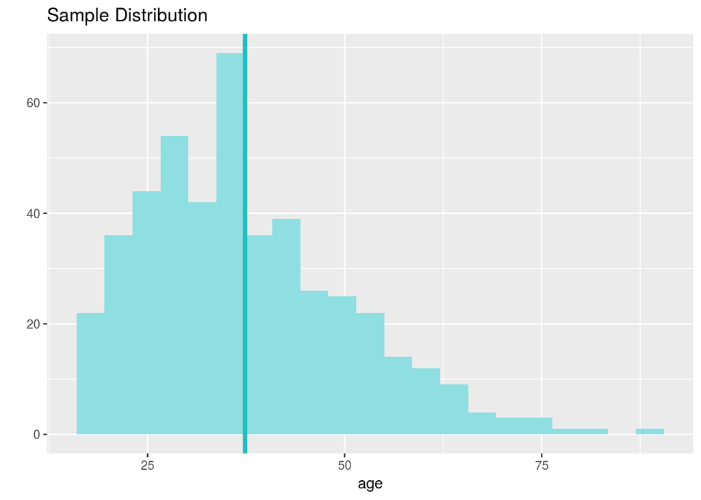

We are 95% confident that the true mean age of people killed by police in the U.S. in 2015 is between 36.18 and 38.55 years old.

$\textbf{95% CI for the mean age of people who were black and killed by police:}$

```
## Single numerical variable
## n = 135, y-bar = 34.0444, s = 11.4409
## 95% CI: (32.0969 , 35.992)
```

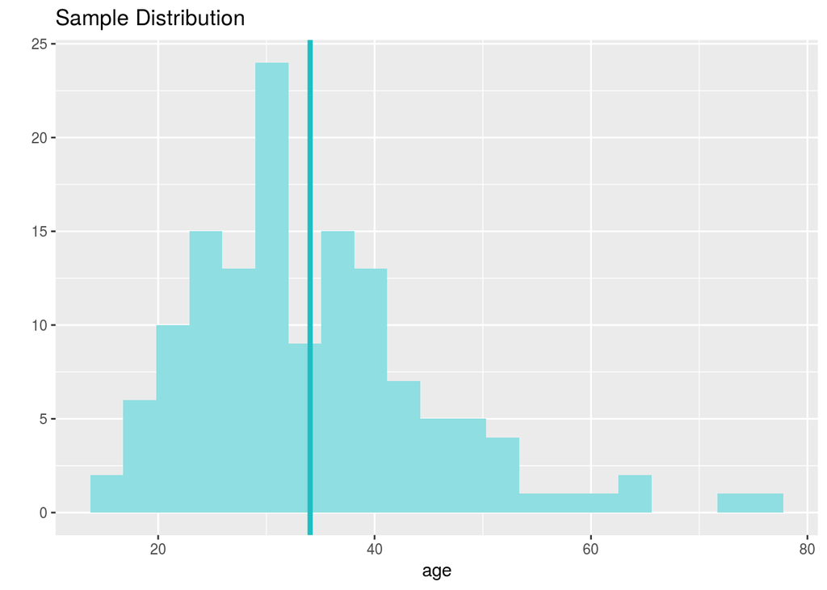

$\textbf{95% Confidence interval for difference in mean age between armed and unarmed:}$

```
## Response variable: numerical, Explanatory variable: categorical (2 levels)
## n_TRUE = 335, y_bar_TRUE = 36.8627, s_TRUE = 12.4825
## n_FALSE = 128, y_bar_FALSE = 38.6875, s_FALSE = 14.2236
## 95% CI (TRUE - FALSE): (-4.6551 , 1.0054)
```

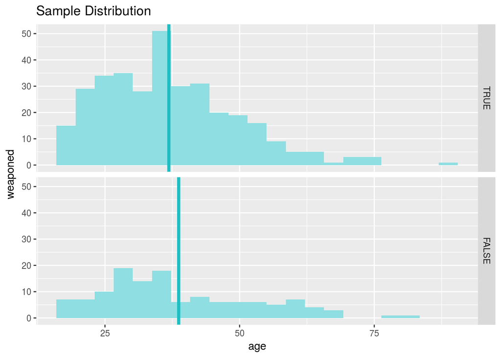

We are 95% confident that the true difference between the mean age of those who were armed and mean age of those who were unarmed who were killed by police for our population is between -4.66 and 1.01 years. 0 is included in our interval so this means that it is very possible that there is no difference in mean age based on whether or not the person is weaponed.

$\textbf {Hypothesis Test: Difference in proportions of unarmed women and unarmed men:}$

```
##
##         Female Male
##   FALSE      4  126
##   TRUE      18  319
```

```
##
##         Female Male Sum
##   FALSE      4  126 130
##   TRUE      18  319 337
##   Sum       22  445 467
```

```
##
##  2-sample test for equality of proportions with continuity
##  correction
##
## data:  c(4, 126) out of c(22, 445)
## X-squared = 0.62643, df = 1, p-value = 0.4287
## alternative hypothesis: two.sided
## 95 percent confidence interval:
##  -0.29169445  0.08903868
## sample estimates:
##    prop 1    prop 2
## 0.1818182 0.2831461
```

95% confidence interval: We are 95% confident that the difference between the proportion of women who were unarmed and the proportion of men who were unarmed is between -0.292 and 0.089.

Hypothesis test: We do not have enough evidence (at the 5% Significant level) that there is a difference between the proportion of unarmed women killed by police and the proportion of unarmed men killed by police. We do not have enough evidence that the proportion of unarmed individuals that were killed by police that is significantly different between men and women

$\textbf{Hypothesis test: [Age] vs. [Whether or not Armed]}$

```
## Response variable: numerical
## Explanatory variable: categorical (2 levels)
## n_FALSE = 128, y_bar_FALSE = 38.6875, s_FALSE = 14.2236
## n_TRUE = 335, y_bar_TRUE = 36.8627, s_TRUE = 12.4825
## H0: mu_FALSE =  mu_TRUE
## HA: mu_FALSE != mu_TRUE
## t = 1.2759, df = 127
## p_value = 0.2043
```

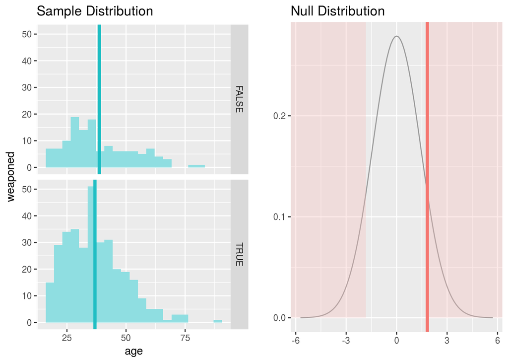

There is not enough statistically significant (at the 5% level) evidence for us to reasonably conclude that there is a difference between the average age of those who were killed by police who were unarmed and the average age of those who were armed when killed by police.

$\textbf{Hypothesis test: [Age] vs. [Gender]}$

```
## Response variable: numerical
## Explanatory variable: categorical (2 levels)
## n_Female = 21, y_bar_Female = 35.5714, s_Female = 11.9982
## n_Male = 442, y_bar_Male = 37.4525, s_Male = 13.0491
## H0: mu_Female =  mu_Male
## HA: mu_Female != mu_Male
## t = -0.6991, df = 20
## p_value = 0.4926
```

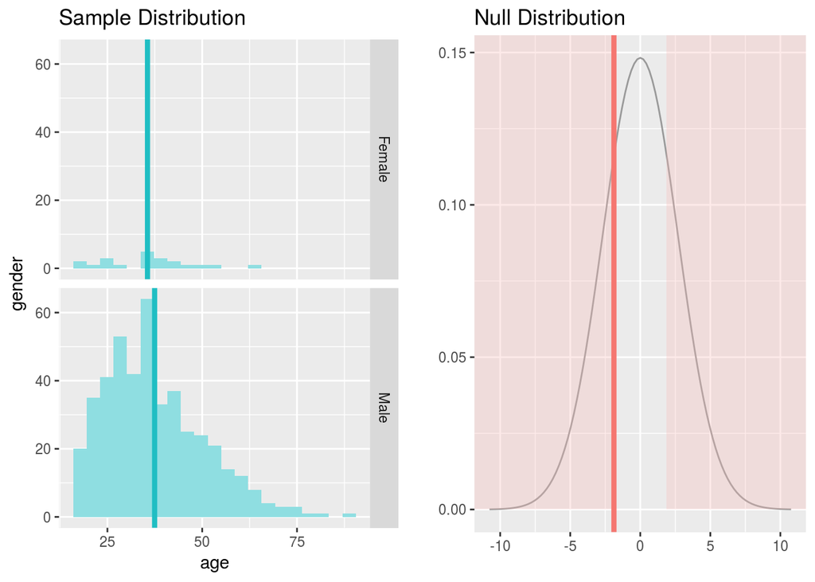

There is not enough statistically significant (at the 5% level) evidence for us to reasonably conclude that there is a difference between the average age of those who were killed by police who were female and the average age of those who were male and killed by police.

$\textbf{ Simple Linear Regression Model}$

```
##
## Call:
## lm(formula = age ~ pov, data = police_killings_clean)
##
## Residuals:
##     Min      1Q  Median      3Q     Max
## -22.410  -9.645  -2.139   8.052  48.051
##
## Coefficients:
##             Estimate Std. Error t value Pr(>|t|)
## (Intercept) 39.67989    1.13067  35.094   <2e-16 ***
## pov         -0.11241    0.04532  -2.481   0.0135 *
## ---
## Signif. codes:  0 '***' 0.001 '**' 0.01 '*' 0.05 '.' 0.1 ' ' 1
##
## Residual standard error: 12.9 on 459 degrees of freedom
##   (6 observations deleted due to missingness)
## Multiple R-squared:  0.01323,    Adjusted R-squared:  0.01108
## F-statistic: 6.153 on 1 and 459 DF,  p-value: 0.01347
```

This model tells us that the the predicted age of the person decreases by 0.11 years when the poverty rate of the city where the killing took place goes up by 1% point. We can conclude that there is a negative linear association between poverty rate of the city where killing took place and the age of the person killed, if there are no confounders and poverty is the only variable.

$\textbf{CHI-Square Test for Region and Whether or not person was armed:}$

```
##
##         East MidWest South West
##   FALSE   29      23    42   36
##   TRUE    97      44    76  120
```

```
##
##         East MidWest South West Sum
##   FALSE   29      23    42   36 130
##   TRUE    97      44    76  120 337
##   Sum    126      67   118  156 467
```

```
##
##         East MidWest South West
##   FALSE   29      23    42   36
##   TRUE    97      44    76  120
```

```
##
##             East  MidWest    South      West
##   FALSE 35.07495 18.65096 32.84797  43.42612
##   TRUE  90.92505 48.34904 85.15203 112.57388
```

```
##
##  Pearson's Chi-squared test
##
## data:  table3
## X-squared = 8.1567, df = 3, p-value = 0.04288
```

We have strong enough statistical evidence (at the 5% level) to conclude that the region of the killing and whether or not the person was armed when they were killed by the police are associated.

$\textbf{CHI-square Test for Race/Ethnicity and Whether or not weaponed:}$

```
##
##         Black Hispanic/Latino Other White
##   FALSE    40              17     7    66
##   TRUE     95              50    22   170
```

```
##
##         Black Hispanic/Latino Other White
##   FALSE    40              17     7    66
##   TRUE     95              50    22   170
```

```
##
##           Black Hispanic/Latino     Other     White
##   FALSE 37.5803        18.65096  8.072805  65.69593
##   TRUE  97.4197        48.34904 20.927195 170.30407
```

```
##
##  Pearson's Chi-squared test
##
## data:  table2
## X-squared = 0.61793, df = 3, p-value = 0.8923
```

```
##
##         Black Hispanic/Latino Other White Sum
##   FALSE    40              17     7    66 130
##   TRUE     95              50    22   170 337
##   Sum     135              67    29   236 467
```

We don’t have strong enough statistical evidence (at the 5% level) to conclude that the race/ethnicity of the person and whether or not the person was armed when they were killed police are associated.